# SQ w23

## Shared Qs (w23)

#### Question

1. A lottery machine (population) will produce random numbers with replacement. It has 4 balls, with the following numbers:

   | $x_i$ |
   | --- |
   | 40 |
   | 58 |
   | 50 |
   | 56 |

   Please calculate the population standard deviation. To do this, first calculate the population mean.

   $$\mu = \frac{\sum\limits_{i=1}^n x_i}{n}$$

   Calculate the population variance by averaging the squared deviations.
   $$\text{variance} = \sigma^2 = \frac{\sum\limits_{i=1}^n (x_i-\mu)^2}{n}$$

   Determine the population standard deviation by taking the square root of the population variance.
   $$\sigma = \sqrt{\sigma^2}$$

#### Question

2. A lottery machine (population) will produce random numbers with replacement. It has 4 balls, with the following numbers:

   | $x_i$ |
   | --- |
   | 49 |
   | 39 |
   | 33 |
   | 31 |

   Please calculate the population standard deviation. To do this, first calculate the population mean.

   $$\mu = \frac{\sum\limits_{i=1}^n x_i}{n}$$

   Calculate the population variance by averaging the squared deviations.
   $$\text{variance} = \sigma^2 = \frac{\sum\limits_{i=1}^n (x_i-\mu)^2}{n}$$

   Determine the population standard deviation by taking the square root of the population variance.
   $$\sigma = \sqrt{\sigma^2}$$

#### Question

3. A lottery machine (population) will produce random numbers with replacement. It has 5 balls, with the following numbers:

   | $x_i$ |
   | --- |
   | 76 |
   | 76 |
   | 76 |
   | 76 |
   | 71 |

   Please calculate the population standard deviation. To do this, first calculate the population mean.

   $$\mu = \frac{\sum\limits_{i=1}^n x_i}{n}$$

   Calculate the population variance by averaging the squared deviations.
   $$\text{variance} = \sigma^2 = \frac{\sum\limits_{i=1}^n (x_i-\mu)^2}{n}$$

   Determine the population standard deviation by taking the square root of the population variance.
   $$\sigma = \sqrt{\sigma^2}$$

#### Question

4. A lottery machine (population) will produce random numbers with replacement. It has 4 balls, with the following numbers:

   | $x_i$ |
   | --- |
   | 51 |
   | 43 |
   | 49 |
   | 57 |

   Please calculate the population standard deviation. To do this, first calculate the population mean.

   $$\mu = \frac{\sum\limits_{i=1}^n x_i}{n}$$

   Calculate the population variance by averaging the squared deviations.
   $$\text{variance} = \sigma^2 = \frac{\sum\limits_{i=1}^n (x_i-\mu)^2}{n}$$

   Determine the population standard deviation by taking the square root of the population variance.
   $$\sigma = \sqrt{\sigma^2}$$

#### Question

5. A lottery machine (population) will produce random numbers with replacement. It has 6 balls, with the following numbers:

   | $x_i$ |
   | --- |
   | 64 |
   | 59 |
   | 58 |
   | 61 |
   | 59 |
   | 59 |

   Please calculate the population standard deviation. To do this, first calculate the population mean.

   $$\mu = \frac{\sum\limits_{i=1}^n x_i}{n}$$

   Calculate the population variance by averaging the squared deviations.
   $$\text{variance} = \sigma^2 = \frac{\sum\limits_{i=1}^n (x_i-\mu)^2}{n}$$

   Determine the population standard deviation by taking the square root of the population variance.
   $$\sigma = \sqrt{\sigma^2}$$

#### Question

6. A lottery machine (population) will produce random numbers with replacement. It has 6 balls, with the following numbers:

   | $x_i$ |
   | --- |
   | 88 |
   | 90 |
   | 84 |
   | 97 |
   | 96 |
   | 97 |

   Please calculate the population standard deviation. To do this, first calculate the population mean.

   $$\mu = \frac{\sum\limits_{i=1}^n x_i}{n}$$

   Calculate the population variance by averaging the squared deviations.
   $$\text{variance} = \sigma^2 = \frac{\sum\limits_{i=1}^n (x_i-\mu)^2}{n}$$

   Determine the population standard deviation by taking the square root of the population variance.
   $$\sigma = \sqrt{\sigma^2}$$

#### Question

7. A lottery machine (population) will produce random numbers with replacement. It has 5 balls, with the following numbers:

   | $x_i$ |
   | --- |
   | 54 |
   | 67 |
   | 55 |
   | 51 |
   | 63 |

   Please calculate the population standard deviation. To do this, first calculate the population mean.

   $$\mu = \frac{\sum\limits_{i=1}^n x_i}{n}$$

   Calculate the population variance by averaging the squared deviations.
   $$\text{variance} = \sigma^2 = \frac{\sum\limits_{i=1}^n (x_i-\mu)^2}{n}$$

   Determine the population standard deviation by taking the square root of the population variance.
   $$\sigma = \sqrt{\sigma^2}$$

#### Question

8. A lottery machine (population) will produce random numbers with replacement. It has 5 balls, with the following numbers:

   | $x_i$ |
   | --- |
   | 69 |
   | 65 |
   | 63 |
   | 61 |
   | 57 |

   Please calculate the population standard deviation. To do this, first calculate the population mean.

   $$\mu = \frac{\sum\limits_{i=1}^n x_i}{n}$$

   Calculate the population variance by averaging the squared deviations.
   $$\text{variance} = \sigma^2 = \frac{\sum\limits_{i=1}^n (x_i-\mu)^2}{n}$$

   Determine the population standard deviation by taking the square root of the population variance.
   $$\sigma = \sqrt{\sigma^2}$$

#### Question

9. A lottery machine (population) will produce random numbers with replacement. It has 5 balls, with the following numbers:

   | $x_i$ |
   | --- |
   | 48 |
   | 52 |
   | 41 |
   | 50 |
   | 44 |

   Please calculate the population standard deviation. To do this, first calculate the population mean.

   $$\mu = \frac{\sum\limits_{i=1}^n x_i}{n}$$

   Calculate the population variance by averaging the squared deviations.
   $$\text{variance} = \sigma^2 = \frac{\sum\limits_{i=1}^n (x_i-\mu)^2}{n}$$

   Determine the population standard deviation by taking the square root of the population variance.
   $$\sigma = \sqrt{\sigma^2}$$

#### Question

10. A lottery machine (population) will produce random numbers with replacement. It has 4 balls, with the following numbers:

    | $x_i$ |
    | --- |
    | 41 |
    | 49 |
    | 47 |
    | 55 |

    Please calculate the population standard deviation. To do this, first calculate the population mean.

    $$\mu = \frac{\sum\limits_{i=1}^n x_i}{n}$$

    Calculate the population variance by averaging the squared deviations.
    $$\text{variance} = \sigma^2 = \frac{\sum\limits_{i=1}^n (x_i-\mu)^2}{n}$$

    Determine the population standard deviation by taking the square root of the population variance.
    $$\sigma = \sqrt{\sigma^2}$$

#### Question

11. A lottery machine (population) will produce random numbers with replacement. It has 5 balls, with the following numbers:

    | $x_i$ |
    | --- |
    | 44 |
    | 45 |
    | 47 |
    | 43 |
    | 41 |

    Please calculate the population standard deviation. To do this, first calculate the population mean.

    $$\mu = \frac{\sum\limits_{i=1}^n x_i}{n}$$

    Calculate the population variance by averaging the squared deviations.
    $$\text{variance} = \sigma^2 = \frac{\sum\limits_{i=1}^n (x_i-\mu)^2}{n}$$

    Determine the population standard deviation by taking the square root of the population variance.
    $$\sigma = \sqrt{\sigma^2}$$

#### Question

12. A lottery machine (population) will produce random numbers with replacement. It has 6 balls, with the following numbers:

    | $x_i$ |
    | --- |
    | 53 |
    | 52 |
    | 44 |
    | 44 |
    | 46 |
    | 43 |

    Please calculate the population standard deviation. To do this, first calculate the population mean.

    $$\mu = \frac{\sum\limits_{i=1}^n x_i}{n}$$

    Calculate the population variance by averaging the squared deviations.
    $$\text{variance} = \sigma^2 = \frac{\sum\limits_{i=1}^n (x_i-\mu)^2}{n}$$

    Determine the population standard deviation by taking the square root of the population variance.
    $$\sigma = \sqrt{\sigma^2}$$

#### Question

13. A lottery machine (population) will produce random numbers with replacement. It has 5 balls, with the following numbers:

    | $x_i$ |
    | --- |
    | 41 |
    | 38 |
    | 37 |
    | 39 |
    | 35 |

    Please calculate the population standard deviation. To do this, first calculate the population mean.

    $$\mu = \frac{\sum\limits_{i=1}^n x_i}{n}$$

    Calculate the population variance by averaging the squared deviations.
    $$\text{variance} = \sigma^2 = \frac{\sum\limits_{i=1}^n (x_i-\mu)^2}{n}$$

    Determine the population standard deviation by taking the square root of the population variance.
    $$\sigma = \sqrt{\sigma^2}$$

#### Question

14. A lottery machine (population) will produce random numbers with replacement. It has 6 balls, with the following numbers:

    | $x_i$ |
    | --- |
    | 48 |
    | 42 |
    | 50 |
    | 53 |
    | 42 |
    | 47 |

    Please calculate the population standard deviation. To do this, first calculate the population mean.

    $$\mu = \frac{\sum\limits_{i=1}^n x_i}{n}$$

    Calculate the population variance by averaging the squared deviations.
    $$\text{variance} = \sigma^2 = \frac{\sum\limits_{i=1}^n (x_i-\mu)^2}{n}$$

    Determine the population standard deviation by taking the square root of the population variance.
    $$\sigma = \sqrt{\sigma^2}$$

#### Question

15. A lottery machine (population) will produce random numbers with replacement. It has 4 balls, with the following numbers:

    | $x_i$ |
    | --- |
    | 85 |
    | 83 |
    | 77 |
    | 83 |

    Please calculate the population standard deviation. To do this, first calculate the population mean.

    $$\mu = \frac{\sum\limits_{i=1}^n x_i}{n}$$

    Calculate the population variance by averaging the squared deviations.
    $$\text{variance} = \sigma^2 = \frac{\sum\limits_{i=1}^n (x_i-\mu)^2}{n}$$

    Determine the population standard deviation by taking the square root of the population variance.
    $$\sigma = \sqrt{\sigma^2}$$

#### Question

16. A lottery machine (population) will produce random numbers with replacement. It has 4 balls, with the following numbers:

    | $x_i$ |
    | --- |
    | 60 |
    | 68 |
    | 62 |
    | 62 |

    Please calculate the population standard deviation. To do this, first calculate the population mean.

    $$\mu = \frac{\sum\limits_{i=1}^n x_i}{n}$$

    Calculate the population variance by averaging the squared deviations.
    $$\text{variance} = \sigma^2 = \frac{\sum\limits_{i=1}^n (x_i-\mu)^2}{n}$$

    Determine the population standard deviation by taking the square root of the population variance.
    $$\sigma = \sqrt{\sigma^2}$$

#### Question

17. A lottery machine (population) will produce random numbers with replacement. It has 6 balls, with the following numbers:

    | $x_i$ |
    | --- |
    | 79 |
    | 82 |
    | 76 |
    | 77 |
    | 71 |
    | 83 |

    Please calculate the population standard deviation. To do this, first calculate the population mean.

    $$\mu = \frac{\sum\limits_{i=1}^n x_i}{n}$$

    Calculate the population variance by averaging the squared deviations.
    $$\text{variance} = \sigma^2 = \frac{\sum\limits_{i=1}^n (x_i-\mu)^2}{n}$$

    Determine the population standard deviation by taking the square root of the population variance.
    $$\sigma = \sqrt{\sigma^2}$$

#### Question

18. A lottery machine (population) will produce random numbers with replacement. It has 6 balls, with the following numbers:

    | $x_i$ |
    | --- |
    | 79 |
    | 73 |
    | 79 |
    | 83 |
    | 71 |
    | 77 |

    Please calculate the population standard deviation. To do this, first calculate the population mean.

    $$\mu = \frac{\sum\limits_{i=1}^n x_i}{n}$$

    Calculate the population variance by averaging the squared deviations.
    $$\text{variance} = \sigma^2 = \frac{\sum\limits_{i=1}^n (x_i-\mu)^2}{n}$$

    Determine the population standard deviation by taking the square root of the population variance.
    $$\sigma = \sqrt{\sigma^2}$$

#### Question

19. A lottery machine (population) will produce random numbers with replacement. It has 5 balls, with the following numbers:

    | $x_i$ |
    | --- |
    | 79 |
    | 77 |
    | 73 |
    | 75 |
    | 76 |

    Please calculate the population standard deviation. To do this, first calculate the population mean.

    $$\mu = \frac{\sum\limits_{i=1}^n x_i}{n}$$

    Calculate the population variance by averaging the squared deviations.
    $$\text{variance} = \sigma^2 = \frac{\sum\limits_{i=1}^n (x_i-\mu)^2}{n}$$

    Determine the population standard deviation by taking the square root of the population variance.
    $$\sigma = \sqrt{\sigma^2}$$

#### Question

20. A lottery machine (population) will produce random numbers with replacement. It has 6 balls, with the following numbers:

    | $x_i$ |
    | --- |
    | 46 |
    | 41 |
    | 50 |
    | 41 |
    | 49 |
    | 55 |

    Please calculate the population standard deviation. To do this, first calculate the population mean.

    $$\mu = \frac{\sum\limits_{i=1}^n x_i}{n}$$

    Calculate the population variance by averaging the squared deviations.
    $$\text{variance} = \sigma^2 = \frac{\sum\limits_{i=1}^n (x_i-\mu)^2}{n}$$

    Determine the population standard deviation by taking the square root of the population variance.
    $$\sigma = \sqrt{\sigma^2}$$

#### Question

21. A large sample ($n=10000$) was gathered and visualized with a histogram.

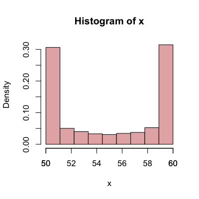

    When a symmetric distribution is sampled thoroughly ($n>100$), you can use the following rules of thumb to **estimate** the mean and standard deviation from a histogram.

    | Shape | Estimated mean | Estimated standard deviation |
    | --- | --- | --- |
    | Bell | $\frac{\min(x)+\max(x)}{2}$ | $\frac{\max(x)-\min(x)}{6}$ |
    | Uniform | $\frac{\min(x)+\max(x)}{2}$ | $\frac{\max(x)-\min(x)}{4}$ |
    | Bimodal | $\frac{\min(x)+\max(x)}{2}$ | $\frac{\max(x)-\min(x)}{2}$ |

    - Estimate the standard deviation of the sample. (Please use the given formula.)

#### Question

22. A large sample ($n=10000$) was gathered and visualized with a histogram.

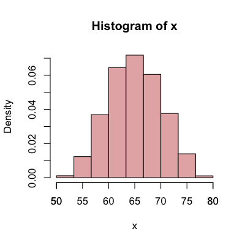

    When a symmetric distribution is sampled thoroughly ($n>100$), you can use the following rules of thumb to **estimate** the mean and standard deviation from a histogram.

    | Shape | Estimated mean | Estimated standard deviation |
    | --- | --- | --- |
    | Bell | $\frac{\min(x)+\max(x)}{2}$ | $\frac{\max(x)-\min(x)}{6}$ |
    | Uniform | $\frac{\min(x)+\max(x)}{2}$ | $\frac{\max(x)-\min(x)}{4}$ |
    | Bimodal | $\frac{\min(x)+\max(x)}{2}$ | $\frac{\max(x)-\min(x)}{2}$ |

    - Estimate the standard deviation of the sample. (Please use the given formula.)

#### Question

23. A large sample ($n=10000$) was gathered and visualized with a histogram.

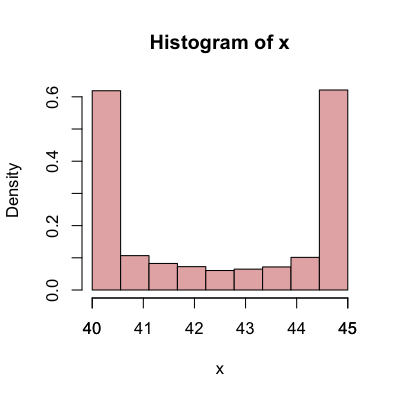

    When a symmetric distribution is sampled thoroughly ($n>100$), you can use the following rules of thumb to **estimate** the mean and standard deviation from a histogram.

    | Shape | Estimated mean | Estimated standard deviation |
    | --- | --- | --- |
    | Bell | $\frac{\min(x)+\max(x)}{2}$ | $\frac{\max(x)-\min(x)}{6}$ |
    | Uniform | $\frac{\min(x)+\max(x)}{2}$ | $\frac{\max(x)-\min(x)}{4}$ |
    | Bimodal | $\frac{\min(x)+\max(x)}{2}$ | $\frac{\max(x)-\min(x)}{2}$ |

    - Estimate the standard deviation of the sample. (Please use the given formula.)

#### Question

24. A large sample ($n=10000$) was gathered and visualized with a histogram.

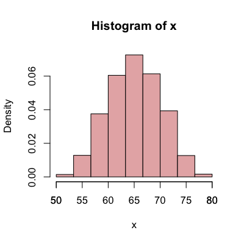

    When a symmetric distribution is sampled thoroughly ($n>100$), you can use the following rules of thumb to **estimate** the mean and standard deviation from a histogram.

    | Shape | Estimated mean | Estimated standard deviation |
    | --- | --- | --- |
    | Bell | $\frac{\min(x)+\max(x)}{2}$ | $\frac{\max(x)-\min(x)}{6}$ |
    | Uniform | $\frac{\min(x)+\max(x)}{2}$ | $\frac{\max(x)-\min(x)}{4}$ |
    | Bimodal | $\frac{\min(x)+\max(x)}{2}$ | $\frac{\max(x)-\min(x)}{2}$ |

    - Estimate the standard deviation of the sample. (Please use the given formula.)

#### Question

25. A large sample ($n=10000$) was gathered and visualized with a histogram.

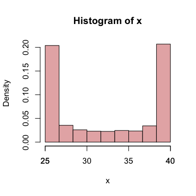

    When a symmetric distribution is sampled thoroughly ($n>100$), you can use the following rules of thumb to **estimate** the mean and standard deviation from a histogram.

    | Shape | Estimated mean | Estimated standard deviation |
    | --- | --- | --- |
    | Bell | $\frac{\min(x)+\max(x)}{2}$ | $\frac{\max(x)-\min(x)}{6}$ |
    | Uniform | $\frac{\min(x)+\max(x)}{2}$ | $\frac{\max(x)-\min(x)}{4}$ |
    | Bimodal | $\frac{\min(x)+\max(x)}{2}$ | $\frac{\max(x)-\min(x)}{2}$ |

    - Estimate the standard deviation of the sample. (Please use the given formula.)

#### Question

26. A large sample ($n=10000$) was gathered and visualized with a histogram.

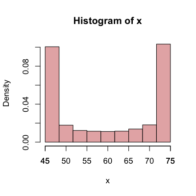

    When a symmetric distribution is sampled thoroughly ($n>100$), you can use the following rules of thumb to **estimate** the mean and standard deviation from a histogram.

    | Shape | Estimated mean | Estimated standard deviation |
    | --- | --- | --- |
    | Bell | $\frac{\min(x)+\max(x)}{2}$ | $\frac{\max(x)-\min(x)}{6}$ |
    | Uniform | $\frac{\min(x)+\max(x)}{2}$ | $\frac{\max(x)-\min(x)}{4}$ |
    | Bimodal | $\frac{\min(x)+\max(x)}{2}$ | $\frac{\max(x)-\min(x)}{2}$ |

    - Estimate the standard deviation of the sample. (Please use the given formula.)

#### Question

27. A large sample ($n=10000$) was gathered and visualized with a histogram.

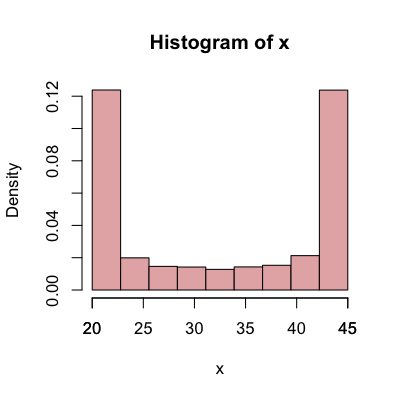

    When a symmetric distribution is sampled thoroughly ($n>100$), you can use the following rules of thumb to **estimate** the mean and standard deviation from a histogram.

    | Shape | Estimated mean | Estimated standard deviation |
    | --- | --- | --- |
    | Bell | $\frac{\min(x)+\max(x)}{2}$ | $\frac{\max(x)-\min(x)}{6}$ |
    | Uniform | $\frac{\min(x)+\max(x)}{2}$ | $\frac{\max(x)-\min(x)}{4}$ |
    | Bimodal | $\frac{\min(x)+\max(x)}{2}$ | $\frac{\max(x)-\min(x)}{2}$ |

    - Estimate the standard deviation of the sample. (Please use the given formula.)

#### Question

28. A large sample ($n=10000$) was gathered and visualized with a histogram.

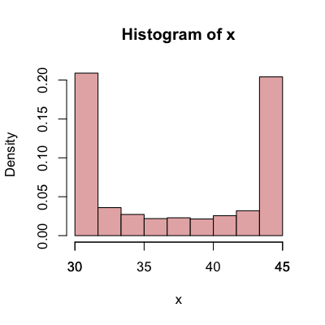

    When a symmetric distribution is sampled thoroughly ($n>100$), you can use the following rules of thumb to **estimate** the mean and standard deviation from a histogram.

    | Shape | Estimated mean | Estimated standard deviation |
    | --- | --- | --- |
    | Bell | $\frac{\min(x)+\max(x)}{2}$ | $\frac{\max(x)-\min(x)}{6}$ |
    | Uniform | $\frac{\min(x)+\max(x)}{2}$ | $\frac{\max(x)-\min(x)}{4}$ |
    | Bimodal | $\frac{\min(x)+\max(x)}{2}$ | $\frac{\max(x)-\min(x)}{2}$ |

    - Estimate the standard deviation of the sample. (Please use the given formula.)

#### Question

29. A large sample ($n=10000$) was gathered and visualized with a histogram.

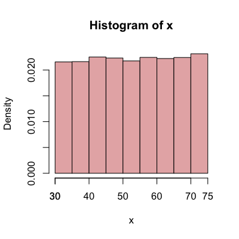

    When a symmetric distribution is sampled thoroughly ($n>100$), you can use the following rules of thumb to **estimate** the mean and standard deviation from a histogram.

    | Shape | Estimated mean | Estimated standard deviation |
    | --- | --- | --- |
    | Bell | $\frac{\min(x)+\max(x)}{2}$ | $\frac{\max(x)-\min(x)}{6}$ |
    | Uniform | $\frac{\min(x)+\max(x)}{2}$ | $\frac{\max(x)-\min(x)}{4}$ |
    | Bimodal | $\frac{\min(x)+\max(x)}{2}$ | $\frac{\max(x)-\min(x)}{2}$ |

    - Estimate the standard deviation of the sample. (Please use the given formula.)

#### Question

30. A large sample ($n=10000$) was gathered and visualized with a histogram.

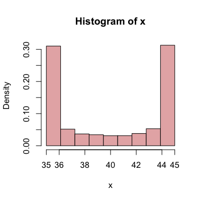

    When a symmetric distribution is sampled thoroughly ($n>100$), you can use the following rules of thumb to **estimate** the mean and standard deviation from a histogram.

    | Shape | Estimated mean | Estimated standard deviation |
    | --- | --- | --- |
    | Bell | $\frac{\min(x)+\max(x)}{2}$ | $\frac{\max(x)-\min(x)}{6}$ |
    | Uniform | $\frac{\min(x)+\max(x)}{2}$ | $\frac{\max(x)-\min(x)}{4}$ |
    | Bimodal | $\frac{\min(x)+\max(x)}{2}$ | $\frac{\max(x)-\min(x)}{2}$ |

    - Estimate the standard deviation of the sample. (Please use the given formula.)

#### Question

31. A large sample ($n=10000$) was gathered and visualized with a histogram.

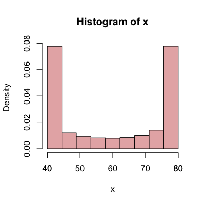

    When a symmetric distribution is sampled thoroughly ($n>100$), you can use the following rules of thumb to **estimate** the mean and standard deviation from a histogram.

    | Shape | Estimated mean | Estimated standard deviation |
    | --- | --- | --- |
    | Bell | $\frac{\min(x)+\max(x)}{2}$ | $\frac{\max(x)-\min(x)}{6}$ |
    | Uniform | $\frac{\min(x)+\max(x)}{2}$ | $\frac{\max(x)-\min(x)}{4}$ |
    | Bimodal | $\frac{\min(x)+\max(x)}{2}$ | $\frac{\max(x)-\min(x)}{2}$ |

    - Estimate the standard deviation of the sample. (Please use the given formula.)

#### Question

32. A large sample ($n=10000$) was gathered and visualized with a histogram.

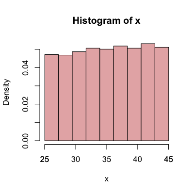

    When a symmetric distribution is sampled thoroughly ($n>100$), you can use the following rules of thumb to **estimate** the mean and standard deviation from a histogram.

    | Shape | Estimated mean | Estimated standard deviation |
    | --- | --- | --- |
    | Bell | $\frac{\min(x)+\max(x)}{2}$ | $\frac{\max(x)-\min(x)}{6}$ |
    | Uniform | $\frac{\min(x)+\max(x)}{2}$ | $\frac{\max(x)-\min(x)}{4}$ |
    | Bimodal | $\frac{\min(x)+\max(x)}{2}$ | $\frac{\max(x)-\min(x)}{2}$ |

    - Estimate the standard deviation of the sample. (Please use the given formula.)

#### Question

33. A large sample ($n=10000$) was gathered and visualized with a histogram.

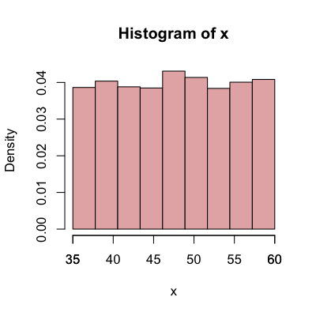

    When a symmetric distribution is sampled thoroughly ($n>100$), you can use the following rules of thumb to **estimate** the mean and standard deviation from a histogram.

    | Shape | Estimated mean | Estimated standard deviation |
    | --- | --- | --- |
    | Bell | $\frac{\min(x)+\max(x)}{2}$ | $\frac{\max(x)-\min(x)}{6}$ |
    | Uniform | $\frac{\min(x)+\max(x)}{2}$ | $\frac{\max(x)-\min(x)}{4}$ |
    | Bimodal | $\frac{\min(x)+\max(x)}{2}$ | $\frac{\max(x)-\min(x)}{2}$ |

    - Estimate the standard deviation of the sample. (Please use the given formula.)

#### Question

34. A large sample ($n=10000$) was gathered and visualized with a histogram.

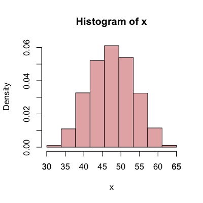

    When a symmetric distribution is sampled thoroughly ($n>100$), you can use the following rules of thumb to **estimate** the mean and standard deviation from a histogram.

    | Shape | Estimated mean | Estimated standard deviation |
    | --- | --- | --- |
    | Bell | $\frac{\min(x)+\max(x)}{2}$ | $\frac{\max(x)-\min(x)}{6}$ |
    | Uniform | $\frac{\min(x)+\max(x)}{2}$ | $\frac{\max(x)-\min(x)}{4}$ |
    | Bimodal | $\frac{\min(x)+\max(x)}{2}$ | $\frac{\max(x)-\min(x)}{2}$ |

    - Estimate the standard deviation of the sample. (Please use the given formula.)

#### Question

35. A large sample ($n=10000$) was gathered and visualized with a histogram.

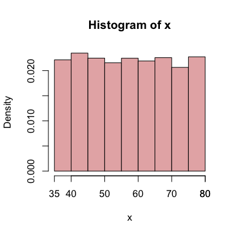

    When a symmetric distribution is sampled thoroughly ($n>100$), you can use the following rules of thumb to **estimate** the mean and standard deviation from a histogram.

    | Shape | Estimated mean | Estimated standard deviation |
    | --- | --- | --- |
    | Bell | $\frac{\min(x)+\max(x)}{2}$ | $\frac{\max(x)-\min(x)}{6}$ |
    | Uniform | $\frac{\min(x)+\max(x)}{2}$ | $\frac{\max(x)-\min(x)}{4}$ |
    | Bimodal | $\frac{\min(x)+\max(x)}{2}$ | $\frac{\max(x)-\min(x)}{2}$ |

    - Estimate the standard deviation of the sample. (Please use the given formula.)

#### Question

36. A large sample ($n=10000$) was gathered and visualized with a histogram.

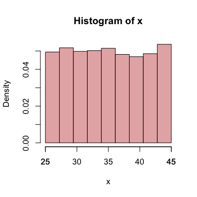

    When a symmetric distribution is sampled thoroughly ($n>100$), you can use the following rules of thumb to **estimate** the mean and standard deviation from a histogram.

    | Shape | Estimated mean | Estimated standard deviation |
    | --- | --- | --- |
    | Bell | $\frac{\min(x)+\max(x)}{2}$ | $\frac{\max(x)-\min(x)}{6}$ |
    | Uniform | $\frac{\min(x)+\max(x)}{2}$ | $\frac{\max(x)-\min(x)}{4}$ |
    | Bimodal | $\frac{\min(x)+\max(x)}{2}$ | $\frac{\max(x)-\min(x)}{2}$ |

    - Estimate the standard deviation of the sample. (Please use the given formula.)

#### Question

37. A large sample ($n=10000$) was gathered and visualized with a histogram.

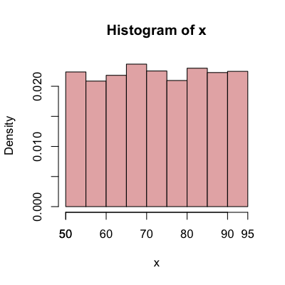

    When a symmetric distribution is sampled thoroughly ($n>100$), you can use the following rules of thumb to **estimate** the mean and standard deviation from a histogram.

    | Shape | Estimated mean | Estimated standard deviation |
    | --- | --- | --- |
    | Bell | $\frac{\min(x)+\max(x)}{2}$ | $\frac{\max(x)-\min(x)}{6}$ |
    | Uniform | $\frac{\min(x)+\max(x)}{2}$ | $\frac{\max(x)-\min(x)}{4}$ |
    | Bimodal | $\frac{\min(x)+\max(x)}{2}$ | $\frac{\max(x)-\min(x)}{2}$ |

    - Estimate the standard deviation of the sample. (Please use the given formula.)

#### Question

38. A large sample ($n=10000$) was gathered and visualized with a histogram.

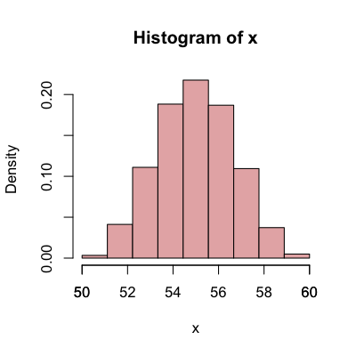

    When a symmetric distribution is sampled thoroughly ($n>100$), you can use the following rules of thumb to **estimate** the mean and standard deviation from a histogram.

    | Shape | Estimated mean | Estimated standard deviation |
    | --- | --- | --- |
    | Bell | $\frac{\min(x)+\max(x)}{2}$ | $\frac{\max(x)-\min(x)}{6}$ |
    | Uniform | $\frac{\min(x)+\max(x)}{2}$ | $\frac{\max(x)-\min(x)}{4}$ |
    | Bimodal | $\frac{\min(x)+\max(x)}{2}$ | $\frac{\max(x)-\min(x)}{2}$ |

    - Estimate the standard deviation of the sample. (Please use the given formula.)

#### Question

39. A large sample ($n=10000$) was gathered and visualized with a histogram.

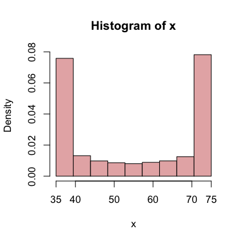

    When a symmetric distribution is sampled thoroughly ($n>100$), you can use the following rules of thumb to **estimate** the mean and standard deviation from a histogram.

    | Shape | Estimated mean | Estimated standard deviation |
    | --- | --- | --- |
    | Bell | $\frac{\min(x)+\max(x)}{2}$ | $\frac{\max(x)-\min(x)}{6}$ |
    | Uniform | $\frac{\min(x)+\max(x)}{2}$ | $\frac{\max(x)-\min(x)}{4}$ |
    | Bimodal | $\frac{\min(x)+\max(x)}{2}$ | $\frac{\max(x)-\min(x)}{2}$ |

    - Estimate the standard deviation of the sample. (Please use the given formula.)

#### Question

40. A large sample ($n=10000$) was gathered and visualized with a histogram.

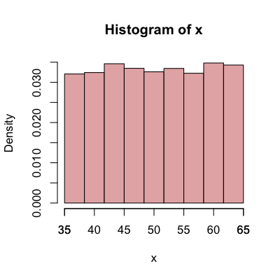

    When a symmetric distribution is sampled thoroughly ($n>100$), you can use the following rules of thumb to **estimate** the mean and standard deviation from a histogram.

    | Shape | Estimated mean | Estimated standard deviation |
    | --- | --- | --- |
    | Bell | $\frac{\min(x)+\max(x)}{2}$ | $\frac{\max(x)-\min(x)}{6}$ |
    | Uniform | $\frac{\min(x)+\max(x)}{2}$ | $\frac{\max(x)-\min(x)}{4}$ |
    | Bimodal | $\frac{\min(x)+\max(x)}{2}$ | $\frac{\max(x)-\min(x)}{2}$ |

    - Estimate the standard deviation of the sample. (Please use the given formula.)